# Analisis De Tesis

Alejandra Escobar

17/5/2020

## Introduccion

El presente documento hace referencia a parte del análisis realizado en la investigación de mi tesis de la carrera de ingeniería en sistemas de la UNAH con la temática sobrepoblación estudiantil dentro de la carrera. En este documento podrá encontrar parte del análisis realizado a información recaudada mediante una encuesta de la cual extraemos una cantidad de variables las cuales serán sometidas a varios test para poder concluir sobre esta información en base a algunas de nuestras preguntas de investigación

## Resumen de nuestra encuesta

```
##                          Marca_temporal    Edad          Genero   Procedencia
##  2020/04/06 11:41:02 a.?m. GMT-5:  2    >38  : 1   Femenino :41   No:83
##  2020/04/04 5:19:57 p.?m. GMT-6 :  1    18-22:32   Masculino:89   Si:47
##  2020/04/04 7:39:30 p.?m. GMT-6 :  1    23-27:79
##  2020/04/04 7:45:12 p.?m. GMT-6 :  1    28-32:17
##  2020/04/05 10:52:02 a.?m. GMT-5:  1    33-37: 1
##  2020/04/06 1:14:09 p.?m. GMT-5 :  1
##  (Other)                        :123
##  Traslado_.UNAH Computadora_.permanente Conexi.n_.permanente Calidad_.conexi.n
##  Muchas:29      No: 10                  No: 24                 :24
##  Normal:62      Si:120                  Si:106               No:35
##  Pocas :39                                                   Si:71
##
##
##
##
##  Estudio_.secundaria Cantidad_.carreras Rango_.acad.mico
##  No:73               No:120             <70   :15
##  Si:57               Si: 10             70-79 :59
##                                         80-89 :46
##                                         90-100:10
##
##
##
##                                      Mejorar_..ndice Exelencia_academica
##  Mejor Planificaci?n                         :38     No:42
##  Flexibilidad de horarios                    :34     Si:88
##  Mejor Planificaci?n;Flexibilidad de horarios:32
##  Otros                                       :10
##  Flexibilidad de horarios;Otros              : 5
##  Mejor Planificaci?n;Otros                   : 5
##  (Other)                                     : 6
##  Reprobaci.n Rango_.promedio_.clases Flexibilidad_.horarios Horas_.libres
##  No: 30      1 a 2 : 6               No:60                  No:48
##  Si:100      2 a 4 :60               Si:70                  Si:82
##              4 a 6 :64
##
##
##
##
```

[output cut: 41 more lines]

```
##  Intermedio:30      No:31    Otras           :34              :10
##  Mucho     :64      Si:99    Moodle          :27    Intermedio:66
##  Poco      :36               Moodle;Otras    :12    Mucho     :17
##                              Wordpress       :12    Poco      :37
##                              Moodle;Wordpress:11
##                                              :10
##                              (Other)         :24
##  Cambio._LMS
##  No:  4
##  Si:126
##
##
##
##
##
```

## Limpiesa de datos

### Tratamiento de valores NA

Creamos un nuevo vector para el tratamiento de valores NA y recorremos la tabla en busca de estos valores NA que son valores vacios encontrados en la encuesta

```
## [1] "Marca_temporal"
## [1] "Edad"
## [1] "Genero"
## [1] "Procedencia"
## [1] "Traslado_.UNAH"
## [1] "Computadora_.permanente"
## [1] "Conexi.n_.permanente"
## [1] "Calidad_.conexi.n"
## [1] "Estudio_.secundaria"
## [1] "Cantidad_.carreras"
## [1] "Rango_.acad.mico"
## [1] "Mejorar_..ndice"
## [1] "Exelencia_academica"
## [1] "Reprobaci.n"
## [1] "Rango_.promedio_.clases"
```

[output cut: 27 more lines]

Observan=mos en la siguiente tabla las variables que presentan este tipo de valores NA que son valores vacios en nuestra encuesta.

Los porcentajes mayores a cero, son los que tiene valores NA

```
##                 column.name na.percentage
## 1 Estimaci.n_.horas_.libres    0.36923077
## 2         Calidad_.conexi.n    0.18461538
## 3              lms_.utiliza    0.07692308
## 4           Estimaci.n_.lms    0.07692308
```

### Tratamiento de valores NA

#### Calidad_conexion

Remplzar los valores NA reemplazar por “NO” debido a que dependia si tenia una conexion permanente a internet o no

```r
paper[is.na(paper$Calidad_.conexi.n), "Calidad_.conexi.n"] <-"No"
```

Mostramos los cambios para la variable Calidad_conexion

```
##
## No Si
## 59 71
```

#### Estimacion_horas_libres

Remplzar los valores NA por “Ninguna” hora libre debido a que no tiene horas libres

```r
paper[is.na(paper$Estimaci.n_.horas_.libres),"Estimaci.n_.horas_.libres"] <- "Ninguna"
```

Mostramos los cambios para la variable Estimacion_horas_libres

```
##
## Intermedias      Muchas     Ninguna       Pocas
##          37          19          48          26
```

#### Estimacion_lms

Remplzar los valores NA por “No utilizo lms” debido a que no se contesto la pregunta porque dependia de si usaba un lms o no

```r
paper[is.na(paper$Estimaci.n_.lms), "Estimaci.n_.lms"] <- "No utilizó LMS"
```

Mostramos los cambios para la variable Estimacion_lms

```
##
##     Intermedio          Mucho No utilizó LMS           Poco
##             66             17             10             37
```

## Analisis Descriptivo

se mostrara un analisis para unas de nuestras variables con el objetivo de ejemplificar el trabajo que se hizo en esta seccion

#### Variable Frecuencia de uso

los resultados nos indican que la mayoria de estudiantes utilizan las plataforma campus virtual de la UNAH en ocasiones con un porcentaje de 66% y solo un 26% indica que lo usa muy frecuentemente

```
##                 Var1       Freq
## 1       En ocasiones 0.66923077
## 2 Muy frecuentemente 0.26153846
## 3              Nunca 0.06923077
```

mediante la funcion boxplot podemos darnos cuenta de que no tenemos valores atipicos para esta variable

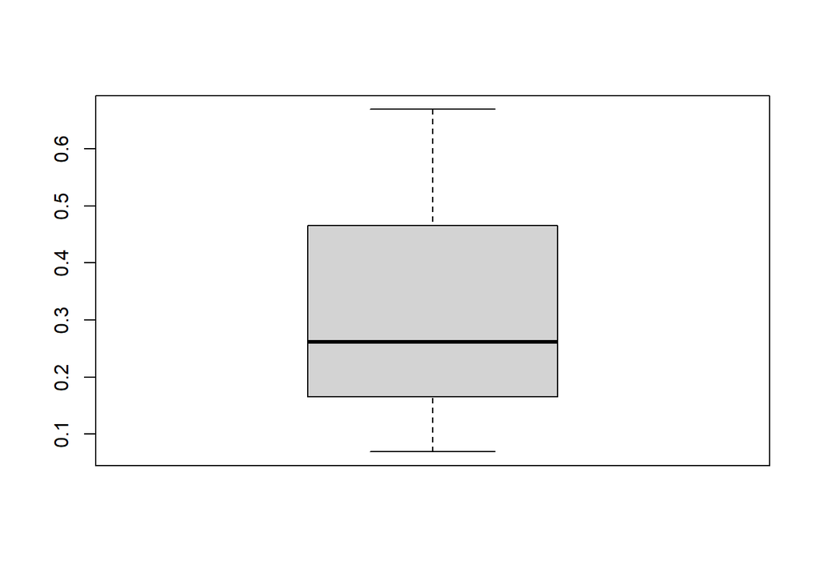

tambien lo podemos ver reflejado mediante un histograma para la distribucion de nuestra vairable que es normal.

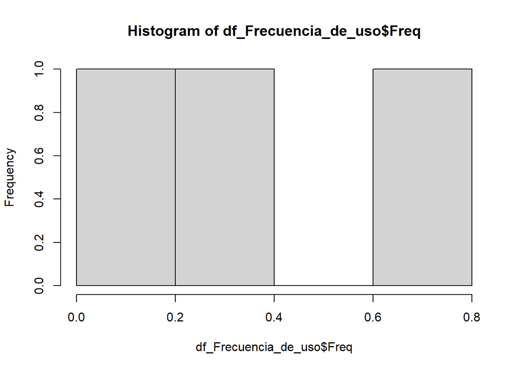

mediante la funcion qqnorm reflejamos tambien que tenemos valores normales y no se presentan valores atipicos.

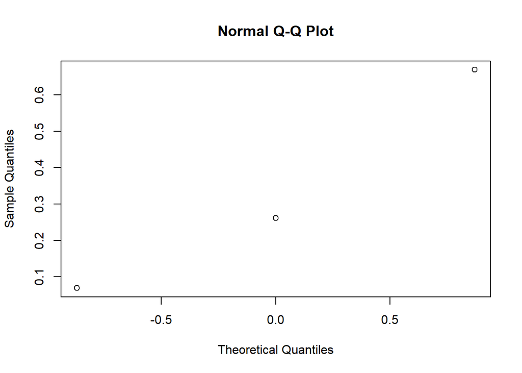

#### Variable Aumento de uso

los resultados nos indican que la mayoria de estudiantes indican que en esta situacion de problematica de pandemia a aumentado el uso de la plataforma capmpus virtual UNAH con un indice de 49% que su aunmento es mucho y un valor de aumento intermedio de 23%, algo interesante es que el 27% indica que el aumento a sido poco quiere decir que hay algunos estudiantes que no conocen los veneficios o no se les exige un uso de este tipo de plataformas

```
##         Var1      Freq
## 1      Mucho 0.4923077
## 2       Poco 0.2769231
## 3 Intermedio 0.2307692
```

mediante la funcion boxplot podemos darnos cuenta de que no tenemos valores atipicos para esta variable

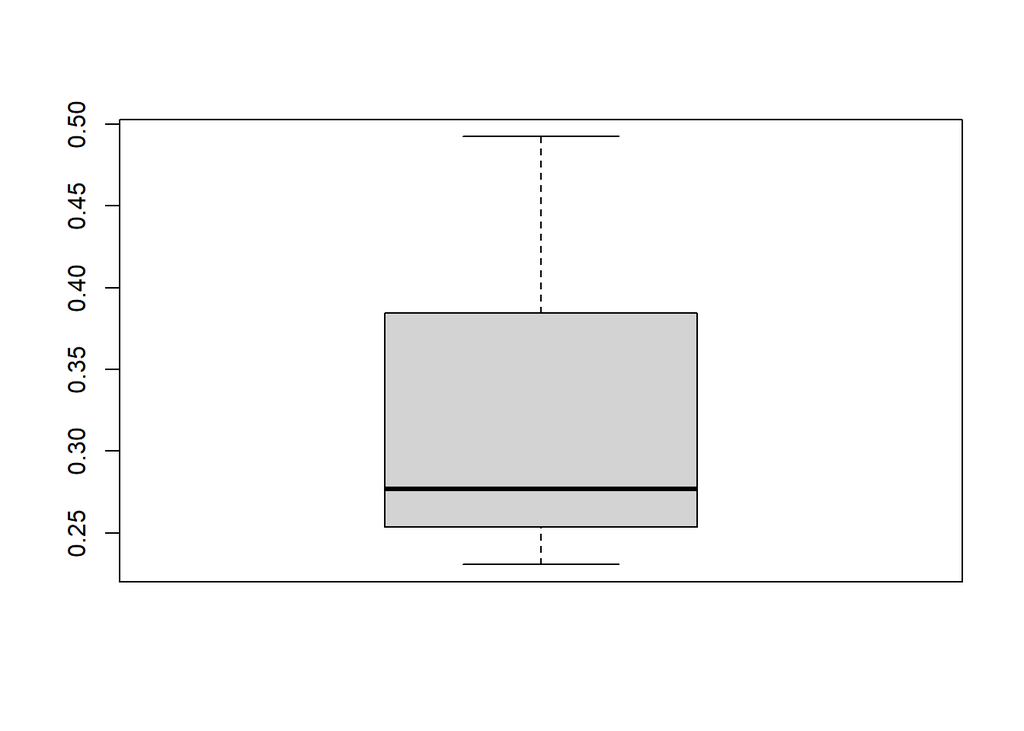

tambien lo podemos ver reflejado mediante un histograma para la distribucion de nuestra vairable que es normal.

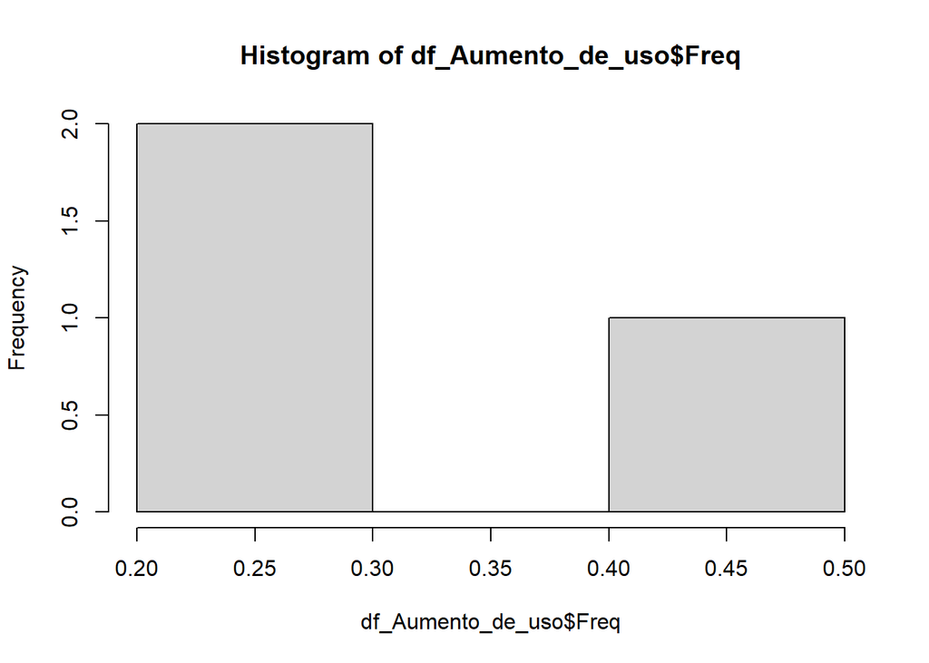

mediante la funcion qqnorm reflejamos tambien que tenemos valores normales y no se presentan valores atipicos.

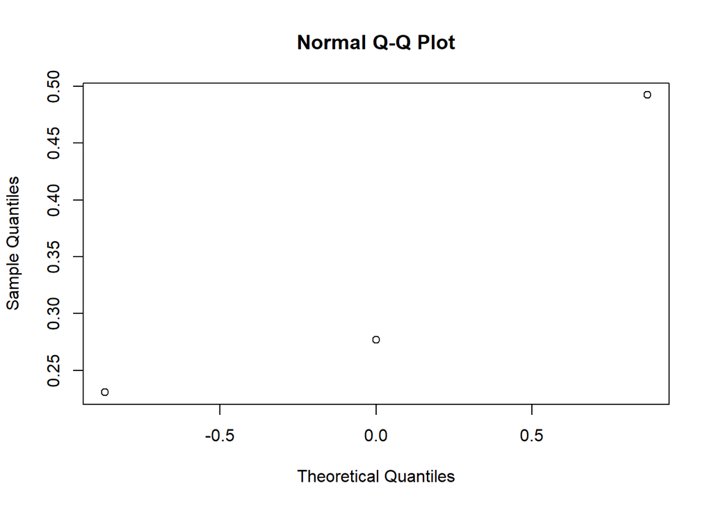

#### Variable Plataforma

los resultados nos indican que la mayoria de estudiantes considera que el uso de este tipo de plataformas son de suma importancia para el estudio hoy endia con un indice del 98% que es lo espera solo algunos estudiantes consideran que no o no llenaron a conciencia la encuesta

```
##   Var1       Freq
## 1   Si 0.98461538
## 2   No 0.01538462
```

mediante la funcion boxplot podemos darnos cuenta de que no tenemos valores atipicos para esta variable

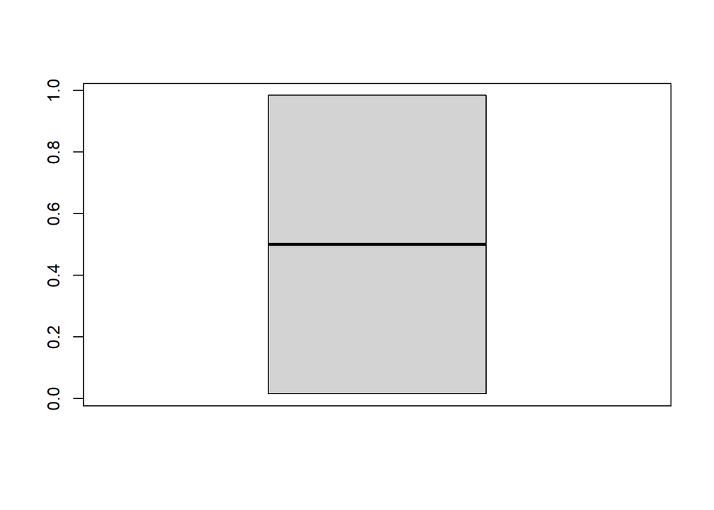

tambien lo podemos ver reflejado mediante un histograma para la distribucion de nuestra vairable que es normal.

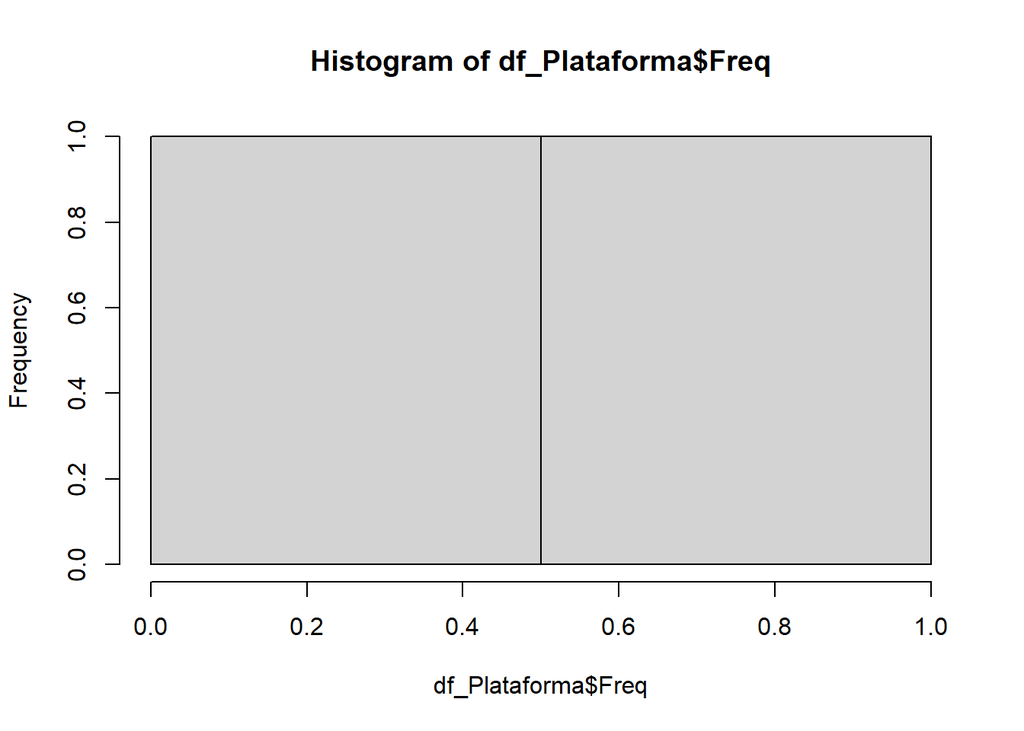

mediante la funcion qqnorm reflejamos tambien que tenemos valores normales y no se presentan valores atipicos.

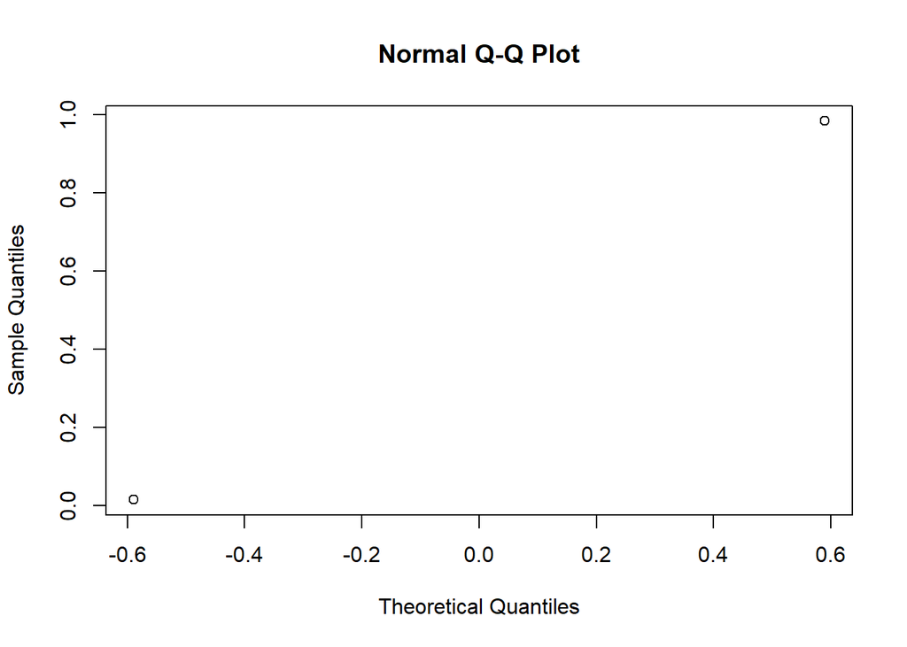

#### Variable Uso lms

```
##   Var1      Freq
## 1   Si 0.7615385
## 2   No 0.2384615
```

mediante la funcion boxplot podemos darnos cuenta de que no tenemos valores atipicos para esta variable

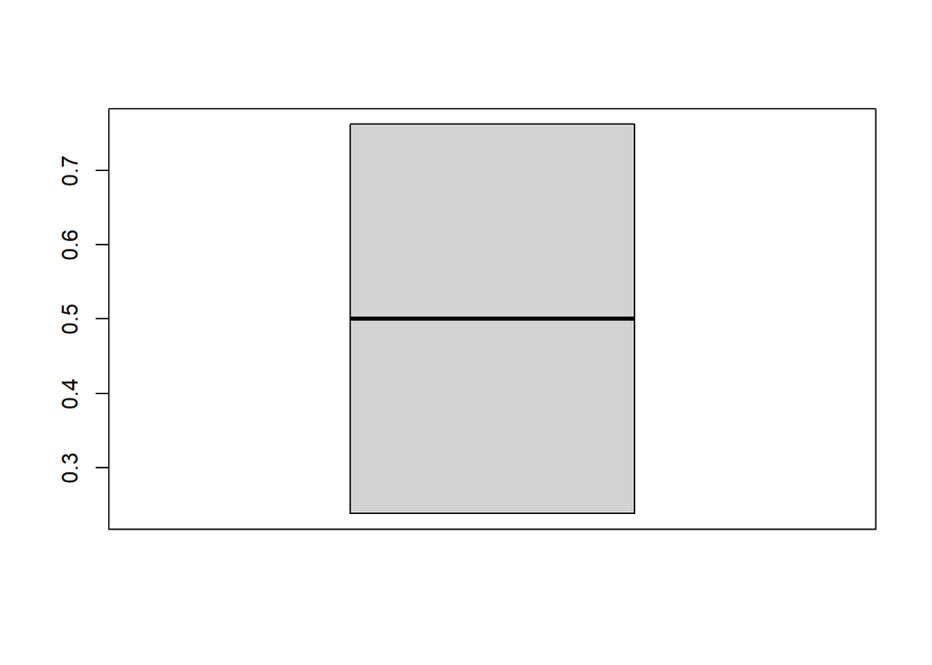

tambien lo podemos ver reflejado mediante un histograma para la distribucion de nuestra vairable que es normal.

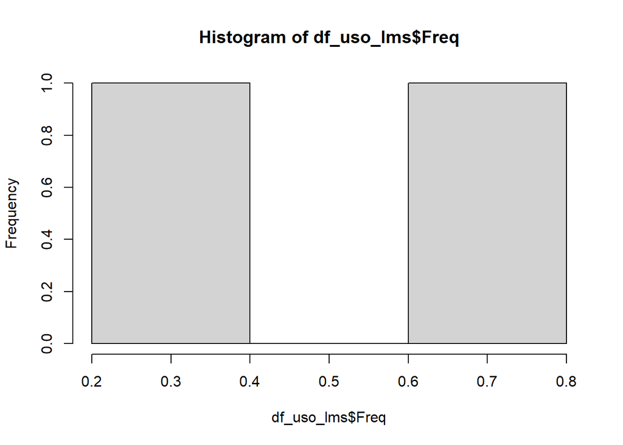

mediante la funcion qqnorm reflejamos tambien que tenemos valores normales y no se presentan valores atipicos.

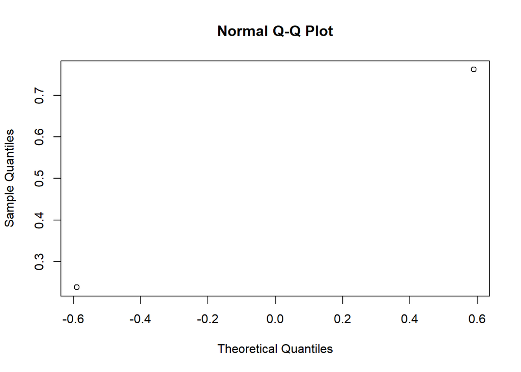

## Análisis Correlacional

Para esta seccion presentamos las siguientes correlaciones entre variables que forman parte de nuetro analisis.

1. Frecuencia_de_uso vs Plataforma
2. Aumento_de_uso vs Plataforma
3. Aumento_de_uso vs Uso_lms

#### Frecuencia_de_uso vs Plataforma

Los resultados reflejan que la mayor cantidad de estudiantes indican que si consideran importante esl usu de plataformas para el estudio actual y que su uso es en ocaciones esto nos indica que se puede mejorar la cantidad de uso que al final es la idea de nuestra propuesta de solucion.

```r
table(survey$Frecuencia_.de_.uso,survey$Plataforma)
```

```
##
##                      No Si
##   En ocasiones        2 85
##   Muy frecuentemente  0 34
##   Nunca               0  9
```

```r
prop.table(table(survey$Frecuencia_.de_.uso,survey$Plataforma),1)
```

```
##
##                              No         Si
##   En ocasiones       0.02298851 0.97701149
##   Muy frecuentemente 0.00000000 1.00000000
##   Nunca              0.00000000 1.00000000
```

Mediante el siguiente grafico podemos apreciar mejor estos resultados,

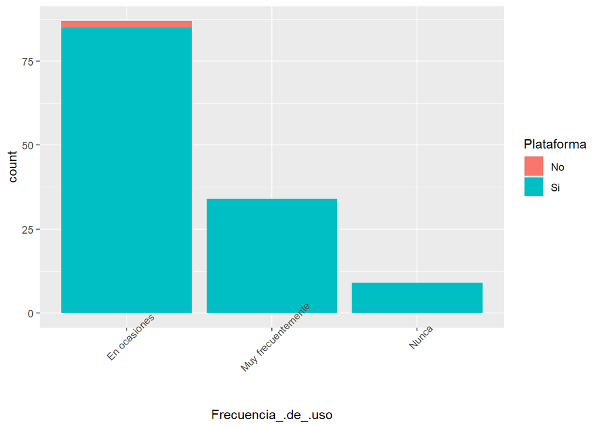

En nuestro analisi nos interesa saber si estas variables correlacionadas son dependientes o independientes para ello aplicamos un test de chi2 para comprobar su dependencia o independencia.

Como regla se establece lo siguiente:

```r
chisq.test(table(survey$Frecuencia_.de_.uso,survey$Plataforma))
```

```
##
##  Pearson's Chi-squared test
##
## data:  table(survey$Frecuencia_.de_.uso, survey$Plataforma)
## X-squared = 1.004, df = 2, p-value = 0.6053
```

H_O Las categorias Frecuencia de uso y Plataforma son Independientes

H_A Las categorias son Dependientes